# Economic Impacts Assessment

### Classification Algorithms = CART

In the nonrespondent application, the decision tree will classify cases using available covariates into classes that are related to their likelihood of being respondents. Advantages of CART compared to propensity modeling are that: 1. Interactions of covariates are handled automatically. 2. The way in which covariates enter the model does not have to be made explicit. 3. Selection of which covariates and associated interactions should be included is done automatically. 4. Variable values, whether categorical or continuous, are combined (grouped) automatically.

```r
require(rpart)
set.seed(15097)
t1 <- rpart(response ~ Service_Connections + Population + Fee_Code +  Median_rent_pct_income +  Median_12month_HH_income,
            method = "class",
            control = rpart.control(minbucket = 20, cp=0), #requires that there be at least 19 cases (responded + nonrespondents) in the final grouping of variable values of the terminal node of the tre..
            data = imputedSmalls.requested.voluntary)
print(t1, digits=4)
```

```
## n= 549
##
## node), split, n, loss, yval, (yprob)
##       * denotes terminal node
##
##   1) root 549 139 1 (0.2532 0.7468)
##     2) Service_Connections< 14.5 25   9 0 (0.6400 0.3600) *
##     3) Service_Connections>=14.5 524 123 1 (0.2347 0.7653)
##       6) Population< 57 43  16 1 (0.3721 0.6279) *
##       7) Population>=57 481 107 1 (0.2225 0.7775)
##        14) Median_12month_HH_income< 4.13e+04 66  20 1 (0.3030 0.6970) *
##        15) Median_12month_HH_income>=4.13e+04 415  87 1 (0.2096 0.7904)
##          30) Service_Connections< 2904 267  64 1 (0.2397 0.7603)
##            60) Median_rent_pct_income< 30.91 131  39 1 (0.2977 0.7023)
##             120) Median_rent_pct_income>=27.4 60  26 1 (0.4333 0.5667)
##               240) Median_rent_pct_income< 28.66 20   8 0 (0.6000 0.4000) *
##               241) Median_rent_pct_income>=28.66 40  14 1 (0.3500 0.6500) *
##             121) Median_rent_pct_income< 27.4 71  13 1 (0.1831 0.8169) *
##            61) Median_rent_pct_income>=30.91 136  25 1 (0.1838 0.8162) *
##          31) Service_Connections>=2904 148  23 1 (0.1554 0.8446) *
```

Plot an interpretable tree.

```
## cex 1   xlim c(0, 1)   ylim c(0, 1)
```

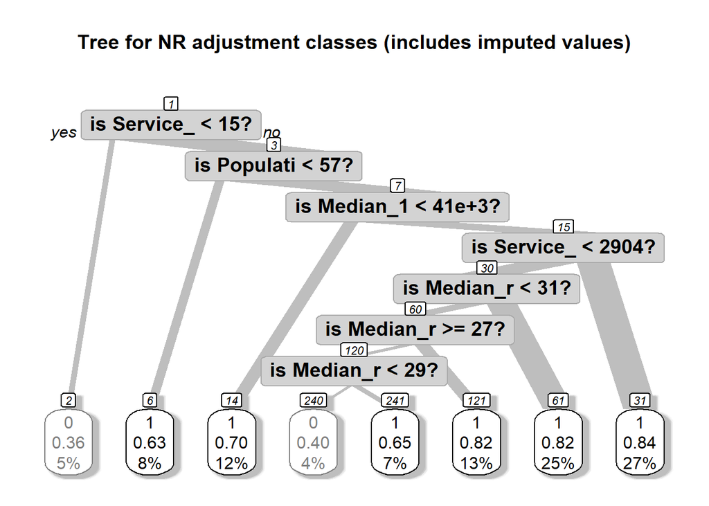

```r
require(rpart.plot)
cols <- ifelse(t1$frame$yval == 1, "gray50", "black")
prp(t1, main="Tree for NR adjustment classes (includes imputed values)",
    extra=106, # display prob of survival and percent of obs
    nn=TRUE, # display node numbers
    fallen.leaves=TRUE, # put leaves on the bottom of page
    branch=.5, # change angle of branch lines
    faclen=0, # do not abbreviate factor levels
    trace=1, # print automatically calculated cex
    shadow.col="gray", # shadows under the leaves
    branch.lty=1, # draw branches using solid lines
    branch.type=5, # branch lines width = weight(frame$wt), no. of cases here
    split.cex=1.2, # make split text larger than node text
    split.prefix="is ", # put "is " before split text
    split.suffix="?", # put "?" after split text
    col=cols, border.col=cols, # cols[2] if survived
    split.box.col="lightgray", # lightgray split boxes (default is white)
    split.border.col="darkgray", # darkgray border on split boxes
    split.round=0.5) # round the split box corners a tad
```

The tree can now be clearly visualized. This exercise will be repeated for the *non-imputed* samples without volunteers.

```r
require(rpart)
set.seed(15097)
t2 <- rpart(response ~ Service_Connections + Population + Fee_Code +  Median_rent_pct_income +  Median_12month_HH_income,
            method = "class",
            control = rpart.control(minbucket = 20, cp=0), #requires that there be at least 19 cases (responded + nonrespondents) in the final grouping of variable values of the terminal node of the tre..
            data = allSmalls.requested)
print(t2, digits=4)
```

```
## n= 510
##
## node), split, n, loss, yval, (yprob)
##       * denotes terminal node
##
##  1) root 510 139 1 (0.2725 0.7275)
##    2) Service_Connections< 14.5 24   8 0 (0.6667 0.3333) *
##    3) Service_Connections>=14.5 486 123 1 (0.2531 0.7469)
##      6) Service_Connections< 2874 319  93 1 (0.2915 0.7085)
##       12) Median_rent_pct_income< 34.33 214  72 1 (0.3364 0.6636)
##         24) Median_rent_pct_income>=27.17 142  56 1 (0.3944 0.6056)
##           48) Median_rent_pct_income< 28.66 25  10 0 (0.6000 0.4000) *
##           49) Median_rent_pct_income>=28.66 117  41 1 (0.3504 0.6496)
##             98) Population< 118 23  11 0 (0.5217 0.4783) *
##             99) Population>=118 94  29 1 (0.3085 0.6915) *
##         25) Median_rent_pct_income< 27.17 72  16 1 (0.2222 0.7778) *
##       13) Median_rent_pct_income>=34.33 105  21 1 (0.2000 0.8000) *
##      7) Service_Connections>=2874 167  30 1 (0.1796 0.8204) *
```

Plot an interpretable tree.

```
## cex 1   xlim c(0, 1)   ylim c(0, 1)
```

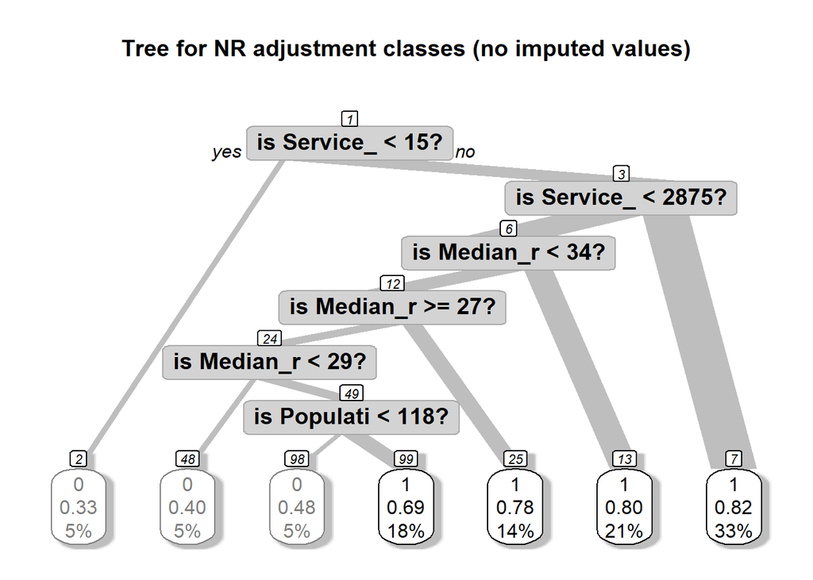

```r
require(rpart.plot)
cols <- ifelse(t2$frame$yval == 1, "gray50", "black")
prp(t2, main="Tree for NR adjustment classes (no imputed values)",
    extra=106, # display prob of survival and percent of obs
    nn=TRUE, # display node numbers
    fallen.leaves=TRUE, # put leaves on the bottom of page
    branch=.5, # change angle of branch lines
    faclen=0, # do not abbreviate factor levels
    trace=1, # print automatically calculated cex
    shadow.col="gray", # shadows under the leaves
    branch.lty=1, # draw branches using solid lines
    branch.type=5, # branch lines width = weight(frame$wt), no. of cases here
    split.cex=1.2, # make split text larger than node text
    split.prefix="is ", # put "is " before split text
    split.suffix="?", # put "?" after split text
    col=cols, border.col=cols, # cols[2] if survived
    split.box.col="lightgray", # lightgray split boxes (default is white)
    split.border.col="darkgray", # darkgray border on split boxes
    split.round=0.5) # round the split box corners a tad
```

### Classification

A single regression tree does tend to overfit the data in the sense of creating a model that may not be accurate for a new dataset (like the units that were not sampled or another sample selected using the same methods that is also subject to nonresponse). For a nonresponse adjustment, the fitted model from a single tree may not be the best representation of the underlying response mechanism. Breiman (2001) formulated random forests as a way of creating predictions that suffer less from this “shrinkage” problem. Random forests fit many regression trees and average the results with the goal of producing more robust, lower variance predictions. Random forests can incorporate a large number of weighting variables and can find complicated relationships between adjustment variables that a researcher may not be aware of in advance( [Zhao et al. 2016](https://www.ncbi.nlm.nih.gov/pmc/articles/PMC4818178/)).

```r
require(party)
crf.srvy <- cforest(as.factor(response) ~ Service_Connections + Fee_Code + Population + Median_rent_pct_income +  Median_12month_HH_income,
                    controls = cforest_control(ntree = 500,
                                               mincriterion = qnorm(0.8),
                                               trace = TRUE), # adds project bar because it's very slow
                    data=imputedSmalls.requested.voluntary)

crfsrvy.prob <- predict(crf.srvy,newdata=imputedSmalls.requested.voluntary,type="prob")
rpart.prob <- predict(t1, newdata=imputedSmalls.requested.voluntary,type="prob")
crf.prob <- matrix(unlist(crfsrvy.prob), ncol=2, byrow=TRUE)
apply(crf.prob,2,mean)
#[1] 0.2524514 0.7475486
tab <- round(cbind(by(rpart.prob[,2], INDICES=t1$where, mean), by(crf.prob[,2], INDICES=t1$where, mean)), 4)
colnames(tab) <- c("rpart", "cforest")
tab
```

[output not shown]

```r
require(party)
crf.srvy.2 <- cforest(as.factor(response) ~ Service_Connections + Fee_Code + Population + Median_rent_pct_income +  Median_12month_HH_income,
                    controls = cforest_control(ntree = 500,
                                               mincriterion = qnorm(0.8),
                                               trace = TRUE), # adds project bar because it's very slow
                    data=allSmalls.requested)

crfsrvy.prob2 <- predict(crf.srvy.2,newdata = allSmalls.requested,type="prob")
rpart.prob2 <- predict(t2, newdata = allSmalls.requested,type="prob")
crf.prob2 <- matrix(unlist(crfsrvy.prob2), ncol=2, byrow=TRUE)
apply(crf.prob2,2,mean)
#[1] 0.2711782 0.7288218
tab <- round(cbind(by(rpart.prob2[,2], INDICES=t2$where, mean), by(crf.prob2[,2], INDICES=t2$where, mean)), 4)
colnames(tab) <- c("rpart (no imputation)", "cforest (no imputation)")
tab
```

Adjusted weights can now be computed and merged into the data file.

```r
##### join to non-imputed data ####
# compute NR adjustments based on classes formed by tree
# Unweighted response rate
unwt.rr <- by(as.numeric(allSmalls.requested[, "response"]), t2$where, mean)
# Weighted response rate
wt.rr <- by(data = data.frame(resp = as.numeric(allSmalls.requested[, "response"]), wt =
                                allSmalls.requested[,"base.weight"]),
            t2$where, function(x) {weighted.mean(x$resp, x$wt)} )
# merge NR class and response rates onto  file
allSmalls.requested.NR <- cbind(allSmalls.requested, NR.class=t2$where)
tmp2 <- cbind(NR.class=as.numeric(names(wt.rr)), unwt.rr, wt.rr)
allSmalls.requested.NR <- merge(allSmalls.requested.NR, data.frame(tmp2), by="NR.class")

allSmalls.requested.NR <- allSmalls.requested.NR[order(allSmalls.requested.NR$PWSID),]
#use inverse of response probabilitiy to generate non-response weight
allSmalls.requested.NR %<>%
  mutate(wt.rr.final = 1/wt.rr) %>%
  mutate(unwt.rr.final = 1/unwt.rr)
#display
allSmalls.requested.NR$wt.rr.final %>%
  unique %>%
  sort
```

```
## [1] 1.206208 1.257031 1.314408 1.325082 2.090909 2.318018 3.000000
```

Here we can see the range of weighted nonresponse weights for the non-imputed survey (without volunteers).We can see below that these weighted nonresponse weights are quite similiar to the unweighted nonreponse weights for the non-imputed survey.

```r
allSmalls.requested.NR$unwt.rr.final %>%
  unique %>%
  sort
```

```
## [1] 1.218978 1.250000 1.285714 1.446154 2.090909 2.500000 3.000000
```

These nonresponse weights are plotted relative to respective baseweights below.

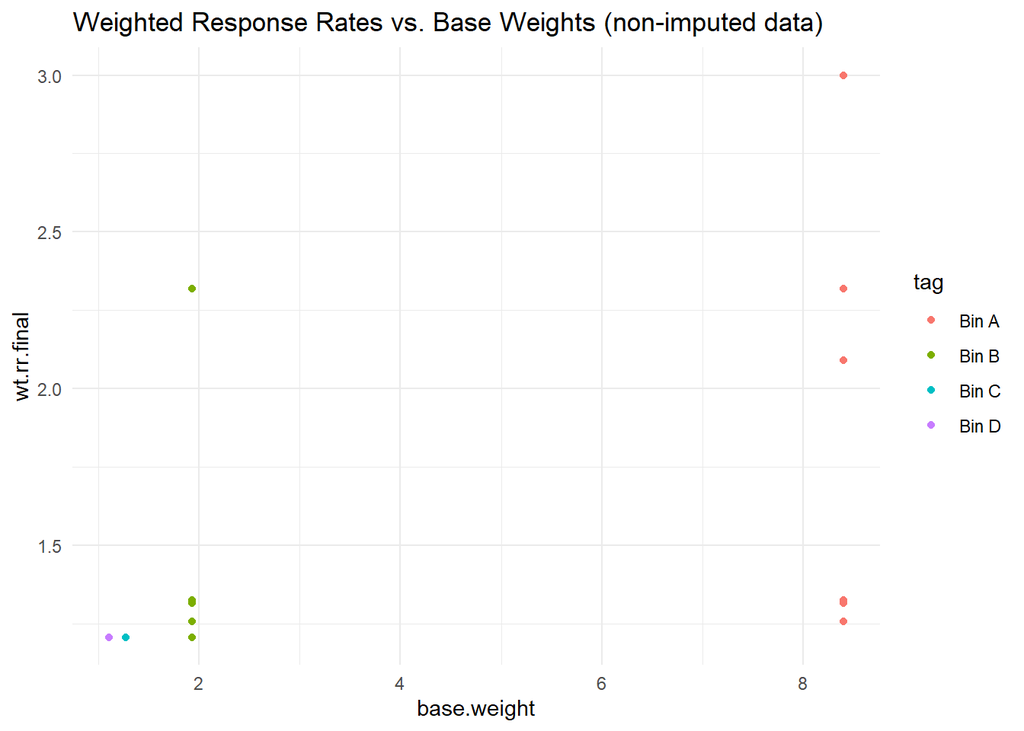

```r
#plot versus base weights
ggplot(data = allSmalls.requested.NR, aes(x = base.weight, y = wt.rr.final, color = tag)) + geom_point() +
  labs(title = "Weighted Response Rates vs. Base Weights (non-imputed data)",
       xlab = "Base Weights",
       ylab = "Weighted Reponse Rates") +
  theme_minimal()
```

```r
# extract base weights and join to data
baseWeights <- allSmalls %>%
  select(PWSID, base.weight, samples, N)

# compute NR adjustments based on classes formed by tree
# Unweighted response rate
unwt.rr <- by(as.numeric(imputedSmalls.requested.voluntary[, "response"]), t1$where, mean)

#join base weights to imputed
imputedSmalls.requested.voluntary <- left_join(imputedSmalls.requested.voluntary, baseWeights, by ="PWSID")

# Weighted response rate
wt.rr <- by(data = data.frame(resp = as.numeric(imputedSmalls.requested.voluntary[, "response"]), wt =
                                imputedSmalls.requested.voluntary[,"base.weight"]),
            t1$where, function(x) {weighted.mean(x$resp, x$wt)} )
# merge NR class and response rates onto  file
imputedSmalls.requested.voluntary.NR <- cbind(imputedSmalls.requested.voluntary, NR.class=t1$where)
tmp1 <- cbind(NR.class=as.numeric(names(wt.rr)), unwt.rr, wt.rr)
imputedSmalls.requested.voluntary.NR <- merge(imputedSmalls.requested.voluntary.NR, data.frame(tmp1), by="NR.class")
imputedSmalls.requested.voluntary.NR <- imputedSmalls.requested.voluntary.NR[order(imputedSmalls.requested.voluntary.NR$PWSID),]
#use inverse of response probabilitiy to generate non-response weight
imputedSmalls.requested.voluntary.NR %<>%
  mutate(wt.rr.final = 1/wt.rr) %>%
  mutate(unwt.rr.final = 1/unwt.rr)

imputedSmalls.requested.voluntary.NR$wt.rr.final %>%
  unique %>%
  sort
```

```
## [1] 1.169516 1.176324 1.234016 1.352643 1.554639 1.592593 2.233819 2.777778
```

The imputed data set contains slightly different weighted nonreponse weights.

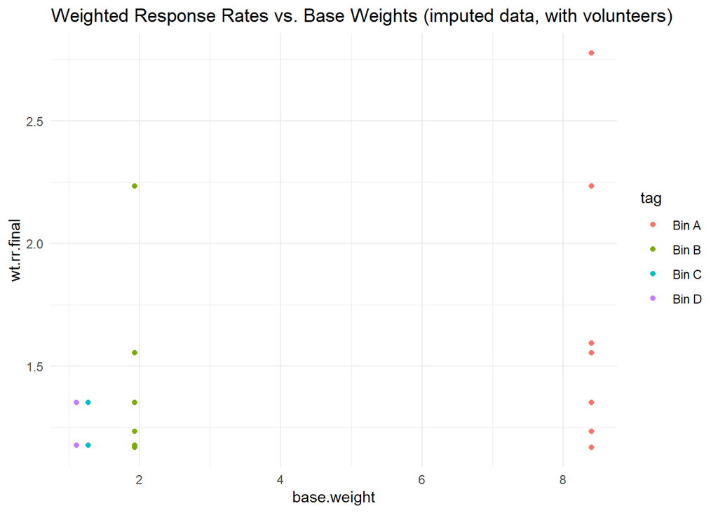

```r
#plot versus base weights
ggplot(data = imputedSmalls.requested.voluntary.NR, aes(x = base.weight, y = wt.rr.final, color = tag)) + geom_point() +
  labs(title = "Weighted Response Rates vs. Base Weights (imputed data, with volunteers)",
       xlab = "Base Weights",
       ylab = "Weighted Reponse Rates") +
  theme_minimal()
```

If we had no information about population estimates, we would end the weighting procedure here. The ‘final weight’ would be the multiplication of both base scaled weight and the scaled non-response weight. Here we will call this new weights ‘final weights’ although we still have to perform adjustments to them and so will not really be ‘final’.

Before going to the next step we will include the computed non-response weights using adjustment classes to the main ‘data’ dataframe object. Then we will drop all non-respondents as we are not going to use them any more in the next steps of our analysis. After that, we will scale the non-response weights to the sample of respondents and multiply the design weights and the non-response weights.

```r
##### Join to non-imputed data #####
#join imputed smalls weights to full data frame
allSmalls %<>%
  left_join(allSmalls.requested.NR %>% select(PWSID,  wt.rr, wt.rr.final, unwt.rr, unwt.rr.final),
            by = "PWSID")

#join non-response weights to just the sample frame
allSmalls.requested.responded %<>%
  left_join(allSmalls.requested.NR %>% select(PWSID,  wt.rr, wt.rr.final, unwt.rr, unwt.rr.final),
            by = "PWSID")

#join the final weights to the respondent list
allSmalls.requested.responded %<>%
  mutate(final.weight.nonresponse = wt.rr.final * base.weight)

#view summary
allSmalls.requested.responded %>%
  select(tag, PWSID, base.weight, final.weight.nonresponse, N, samples) %>%
  group_by(tag) %>%
  summarize(sum.final.weight = sum(final.weight.nonresponse), totalSamples = max(samples), population = max(N), percent.diff = 100*(1 - sum.final.weight/(population)))
```

```
## # A tibble: 4 x 5
##   tag   sum.final.weight totalSamples population percent.diff
##   <fct>            <dbl>        <dbl>      <int>        <dbl>
## 1 Bin A           1933.           228       1914       -0.983
## 2 Bin B            243.           133        257        5.43
## 3 Bin C            106.            84        107        0.919
## 4 Bin D             68.1           65         72        5.36
```

Here we can see that the sum of the weights adjusted for non-response are slightly different from the population. This is fine as they are within 6%. The adjusted weights are plotted below:

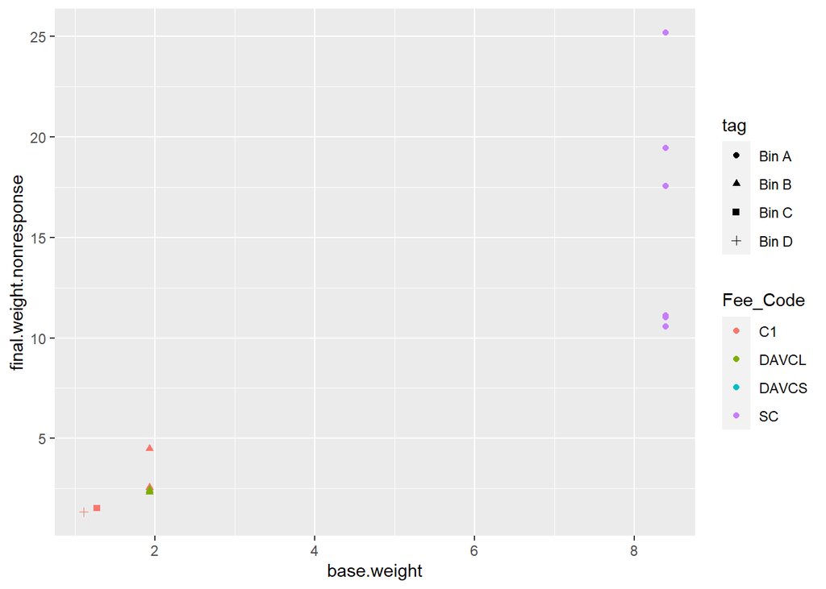

```r
allSmalls.requested.responded %>%
  ggplot(aes(x = base.weight, y =final.weight.nonresponse, color = Fee_Code, shape = tag)) +
  geom_point()
```

We can see clearly that the high non-response in the smaller bins has inflated the base weights.

Repeat these steps for the imputed data.

```r
#join imputed smalls weights to imputed dataset
imputedSmalls %<>%
  left_join(imputedSmalls.requested.voluntary.NR %>% select(PWSID, wt.rr.final, unwt.rr, unwt.rr.final),
            by = "PWSID")

#join non-response weights to just the sample frame
imputedSmalls.requested.voluntary %<>%
  left_join(imputedSmalls.requested.voluntary.NR %>% select(PWSID, wt.rr.final, unwt.rr, unwt.rr.final),
            by = "PWSID")

#join the final weights to the respondent list
imputedSmalls.requested.voluntary %<>%
  mutate(final.weight.nonresponse = wt.rr.final * base.weight) %>%
  mutate(final.weight.nonresponse.unwt = unwt.rr.final * base.weight)

#view summary
imputedSmalls.requested.voluntary %>%
  select(tag, PWSID, base.weight, final.weight.nonresponse, final.weight.nonresponse.unwt, N, samples) %>%
  group_by(tag) %>%
  summarize(sum.final.weight = sum(final.weight.nonresponse), sum.final.weight.unwt.rr = sum(final.weight.nonresponse.unwt), totalSamples = max(samples), population = max(N), percent.diff = 100*(1 - sum.final.weight/(population)))
```

```
## # A tibble: 4 x 6
##   tag   sum.final.weight sum.final.weight.unwt.rr totalSamples population
##   <fct>            <dbl>                    <dbl>        <dbl>      <int>
## 1 Bin A           3305.                    3382.           228       1914
## 2 Bin B            351.                     364.           133        257
## 3 Bin C            130.                     131.            84        107
## 4 Bin D             86.1                     87.2           65         72
##   percent.diff
##          <dbl>
## 1        -72.7
## 2        -36.6
## 3        -21.1
## 4        -19.5
```

We can see that the dataset that included the volunteers dramatically inflates the nonresponse-adjusted weights. This is an unnaceptable difference.

```r
rm(imputedSmalls.requested.voluntary.NR, allSmalls.requested.NR, chk1, chk2, crf.prob2, crfsrvy.prob2, crf.srvy.2, crf.prob, crf.srvy, crfsrvy.prob, fitResponse, allSmalls.requested.response.model, allSmalls.simple, baseWeights, completenessSummary, log.reg.m, out, probSumm, t1, t2, tab, tmp1, tmp2, transposed, x.matrix, rpart.prob, predM, MissingMatrix, scaledSumm, smalls, srv.dsgn, rclus1)
```

## Calibration of Weights

We’ve now generated *base weights* and *nonresponse adjustments* to those weights. The last step, which is extremely important in many surveys, is to use auxiliary data to correct coverage problems and to reduce standard errors.By auxiliary data, we mean information that is available for the entire frame or target population, either for each individual population unit or in aggregate form (i.e. househould income, service connections, population, fee code, regulating agency).Using auxiliary variable to adjust survey variables may reduce variances, but improve the representativeness of the survey.

Since our auxiliary variables are both quantitative(i.e. househould income, service connections, population) and qualitative (fee code, regulating agency), we will use a general regression estimator or GREG approach, which is a type of raking estimator. A GREG is approximately unbiased in repeated sampling if the frame provides full coverage of the target population (in this case we have census data for these auxiliary variables) ( [Vallian et al 2018](http://link.springer.com/10.1007/978-3-319-93632-1)).

### Evaluation of Correlative factors

The first step in selecting appropriate auxiliary variables to use for raking is to deterimine correlations with response variables of interest. This can be achieved using a scatterplot matrix of the quantitative variables in the dataset.

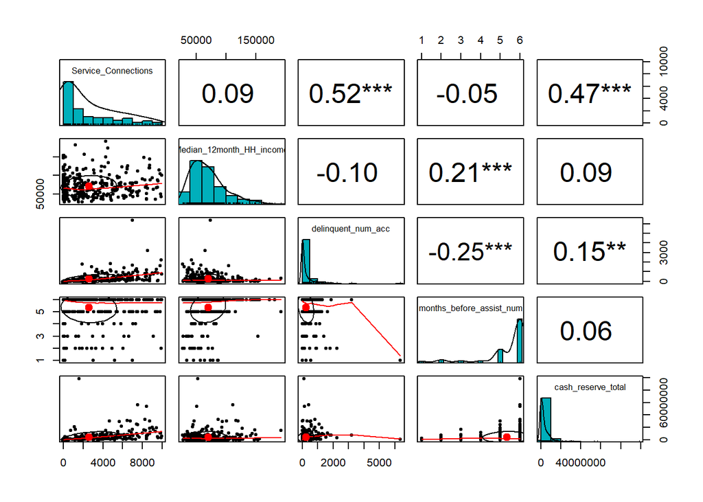

```r
require(psych)
#trim data
aux.response <- allSmalls.requested.responded %>% select(Service_Connections,Median_12month_HH_income, delinquent_num_acc, months_before_assist_num, cash_reserve_total)
# plot matrix
pairs.panels(aux.response,
             method = "pearson",
             hist.col = "#00AFBB", # color
             density = TRUE, #show histograms
             ellipses = TRUE,#annotate correlation elliopses
             stars = TRUE) #show significance)
```

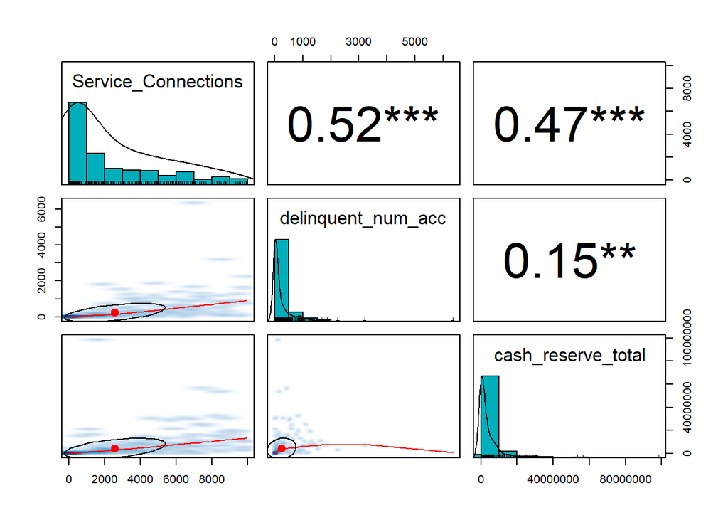

```r
require(psych)
#trim data
aux.response <- allSmalls.requested.responded %>%
  select(Service_Connections, delinquent_num_acc, cash_reserve_total)
# plot matrix
pairs.panels(aux.response,
             method = "pearson",
             hist.col = "#00AFBB", # color
             density = TRUE, #show histograms
             ellipses = TRUE,#annotate correlation elliopses
             smoother = TRUE,
             stars = TRUE) #show significance)
```

We can see that service connections is a useful linear predictor for delinquent number of accounts (r = 0.52) and total cash reserve (r = 0.47). Interestingly, the delinquent number of accoutns and total cash reserves has a very non-linear relationship, resembling a volcano plot.

It may be better to visualize the number of delinquent accounts and cash totals on a log10 scale.

```r
#trim data
aux.response_log <- allSmalls.requested.responded %>%
  select(Service_Connections, delinquent_num_acc, cash_reserve_total) %>%
   mutate(log.d.n.acc = log10(delinquent_num_acc)) %>%
  mutate(log.cash.total = log10(cash_reserve_total)) %>%
  drop_na() %>%
  filter(log.d.n.acc > 0) %>%
  filter(log.cash.total > 0) %>%
  select(Service_Connections, log.d.n.acc, log.cash.total)
```

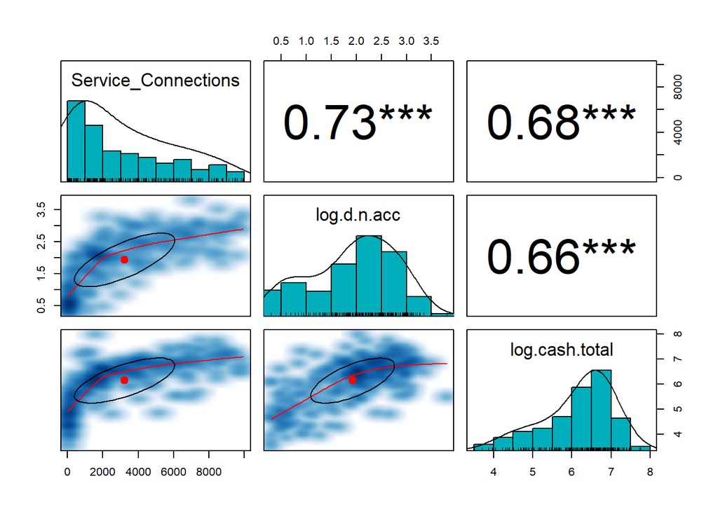

```r
# plot matrix
pairs.panels(aux.response_log,
             method = "pearson",
             hist.col = "#00AFBB", # color
             density = TRUE, #show histograms
             ellipses = TRUE,#annotate correlation elliopses
             smoother = TRUE,
             stars = TRUE) #show significance)
```

After log transformation we can see more linear relationships between the predictor (service connections) and response variables. Delinquent number of accounts normalized to service connections is a critical response variable that may be predicted from auxiliary variables.

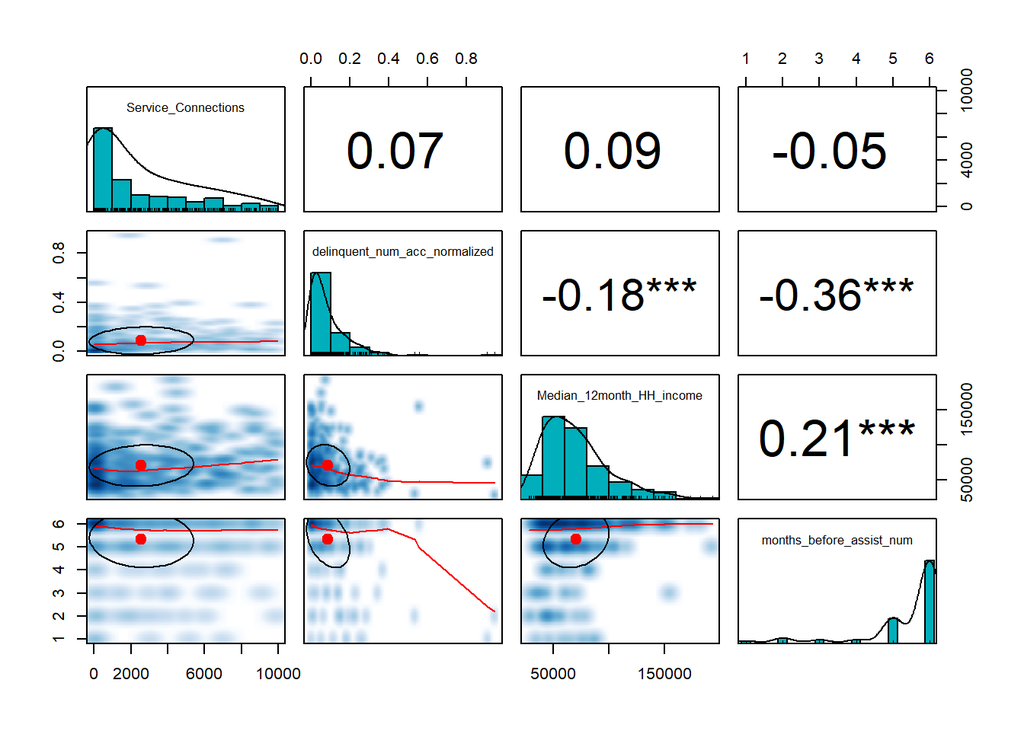

```r
#trim data
aux.response <- allSmalls.requested.responded %>%
  mutate(logServiceConnections = log10(Service_Connections)) %>%
  select(Service_Connections, delinquent_num_acc_normalized, Median_12month_HH_income, months_before_assist_num)
# plot matrix
pairs.panels(aux.response,
             method = "pearson",
             hist.col = "#00AFBB", # color
             density = TRUE, #show histograms
             ellipses = TRUE,#annotate correlation elliopses
             smoother = TRUE,
             stars = TRUE) #show significance)
```

Here we can see that service connections and median 12 month household income are not good predictors of the service-connection *normalized* number of delinquent accounts. However, a strong relationship exists between the *normalized* number of delinquent accounts and the qualitative variable for months before assistance needed. This is not useful for raking, as neither variables are auxiliary, however this is an interesting (and expected) correlation. Again, median 12 month household income and months before assistance needed are significantly correlated.

To continue raking, we will now perform more formal analyses. Using all reliable, complete auxiliary data present, let’s see the linear relationships to the continuous variable months before assistance needed (from factor)

```r
m2 <- glm(months_before_assist_num ~ Service_Connections + Median_12month_HH_income + Median_rent_pct_income + Fee_Code, na.action = na.exclude, data = allSmalls.requested.responded)
summary(m2)
```

```
##
## Call:
## glm(formula = months_before_assist_num ~ Service_Connections +
##     Median_12month_HH_income + Median_rent_pct_income + Fee_Code,
##     data = allSmalls.requested.responded, na.action = na.exclude)
##
## Deviance Residuals:
##     Min       1Q   Median       3Q      Max
## -4.7491  -0.2229   0.3951   0.6825   1.3910
##
## Coefficients:
##                              Estimate   Std. Error t value           Pr(>|t|)
## (Intercept)               4.137306312  0.527438955   7.844 0.0000000000000615
## Service_Connections      -0.000025077  0.000033778  -0.742           0.458373
## Median_12month_HH_income  0.000008711  0.000002563   3.399           0.000761
## Median_rent_pct_income    0.021822315  0.012416149   1.758           0.079750
## Fee_CodeDAVCL            -0.389227265  0.206986478  -1.880           0.060930
## Fee_CodeDAVCS             0.032420714  0.393655413   0.082           0.934412
## Fee_CodeSC                0.015550889  0.209543346   0.074           0.940886
##
## (Intercept)              ***
## Service_Connections
## Median_12month_HH_income ***
## Median_rent_pct_income   .
## Fee_CodeDAVCL            .
## Fee_CodeDAVCS
## Fee_CodeSC
## ---
## Signif. codes:  0 '***' 0.001 '**' 0.01 '*' 0.05 '.' 0.1 ' ' 1
##
## (Dispersion parameter for gaussian family taken to be 1.419319)
##
##     Null deviance: 502.33  on 335  degrees of freedom
## Residual deviance: 466.96  on 329  degrees of freedom
##   (35 observations deleted due to missingness)
## AIC: 1080.1
##
## Number of Fisher Scoring iterations: 2
```

The relationship between fee code and months before assistance needed can be visualized as a boxplot.

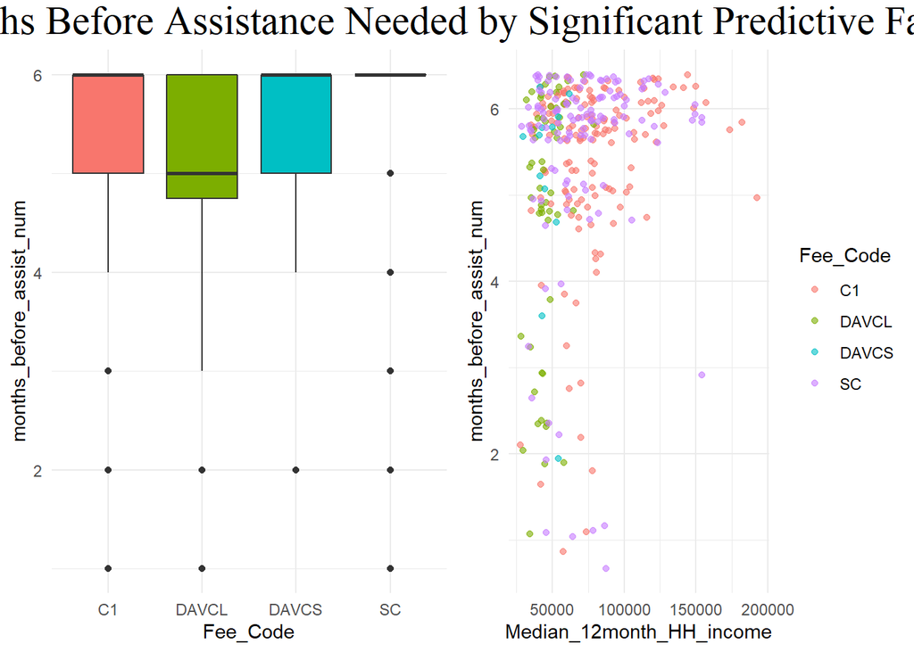

```r
p1 <- allSmalls.requested.responded %>%
  ggplot(aes(x = Fee_Code, y = months_before_assist_num, fill = Fee_Code)) +
  geom_boxplot() +
  theme_minimal() +
  theme(legend.position = "none")
p2 <- allSmalls.requested.responded %>%
  ggplot(aes(x = Median_12month_HH_income, y = months_before_assist_num, color = Fee_Code)) +
  geom_point(position = "jitter", alpha = 0.6) +
  theme_minimal()

grid.arrange(p1, p2,ncol = 2,
             top = textGrob("Months Before Assistance Needed by Significant Predictive Factors",
                            gp=gpar(fontsize = 22,font=6)))
```

We can see quite clearly the relationship between fee code and months before assistance needed, with the disadvantaged community larges representing the most at-risk overall, and the community smalls representing lowest risk. Again remember that these values are unweighted and are only used for selecting auxiliary variables for raking.Nonetheless, the relationship between median 12 month household income and months before assistance needed seems to be quite robust. There are, however, some outliers that may negatively affect raking. We may choose to remove these outliers for raking purposes.

```r
require(car)
#glm for only predictive variables
m3 <- glm(months_before_assist_num ~ Median_12month_HH_income + Fee_Code,na.action = na.exclude,  data = allSmalls.requested.responded)
#  Bonferonni p-value for most extreme obs
outlierTest(m3)
```

```
##      rstudent unadjusted p-value Bonferroni p
## 305 -3.933773        0.000083623     0.028097
## 341 -3.925684        0.000086484     0.029059
## 259 -3.875518        0.000106400     0.035750
```

It seems that three values are extreme outliers.

```r
#code row number
allSmalls.requested.responded %<>%
  mutate(id = row_number())
#examine cases
allSmalls.requested.responded %>%
  filter(id == 305 | id == 341 | id == 259)
```

Here we can see these are quite small systems. The Fisherman’s retreat in Riverside, Belmont manor in Fresno, and Wayside motel apparments in San Joaquin county. The notes indicate that the last one does not have financial information for the water system and the first is just for seven months of expenses. The first and third report no cash reserves. The third reports that many people are not paying rent.All are in relatively moderate income areas (78-86 k/year median). These are important data points that should be considered later, but may innapropriately skew the raking process.

Let’s look at residuals for predictive variables.

```r
summary(m3)
```

```
##
## Call:
## glm(formula = months_before_assist_num ~ Median_12month_HH_income +
##     Fee_Code, data = allSmalls.requested.responded, na.action = na.exclude)
##
## Deviance Residuals:
##     Min       1Q   Median       3Q      Max
## -4.5772  -0.2820   0.4354   0.6860   1.2787
##
## Coefficients:
##                              Estimate   Std. Error t value             Pr(>|t|)
## (Intercept)               4.846150113  0.217354419  22.296 < 0.0000000000000002
## Median_12month_HH_income  0.000007077  0.000002411   2.935              0.00357
## Fee_CodeDAVCL            -0.350304495  0.205185521  -1.707              0.08871
## Fee_CodeDAVCS             0.075870097  0.367880088   0.206              0.83673
## Fee_CodeSC                0.112144482  0.147551287   0.760              0.44777
##
## (Intercept)              ***
## Median_12month_HH_income **
## Fee_CodeDAVCL            .
## Fee_CodeDAVCS
## Fee_CodeSC
## ---
## Signif. codes:  0 '***' 0.001 '**' 0.01 '*' 0.05 '.' 0.1 ' ' 1
##
## (Dispersion parameter for gaussian family taken to be 1.425995)
##
##     Null deviance: 502.33  on 335  degrees of freedom
## Residual deviance: 472.00  on 331  degrees of freedom
##   (35 observations deleted due to missingness)
## AIC: 1079.7
##
## Number of Fisher Scoring iterations: 2
```

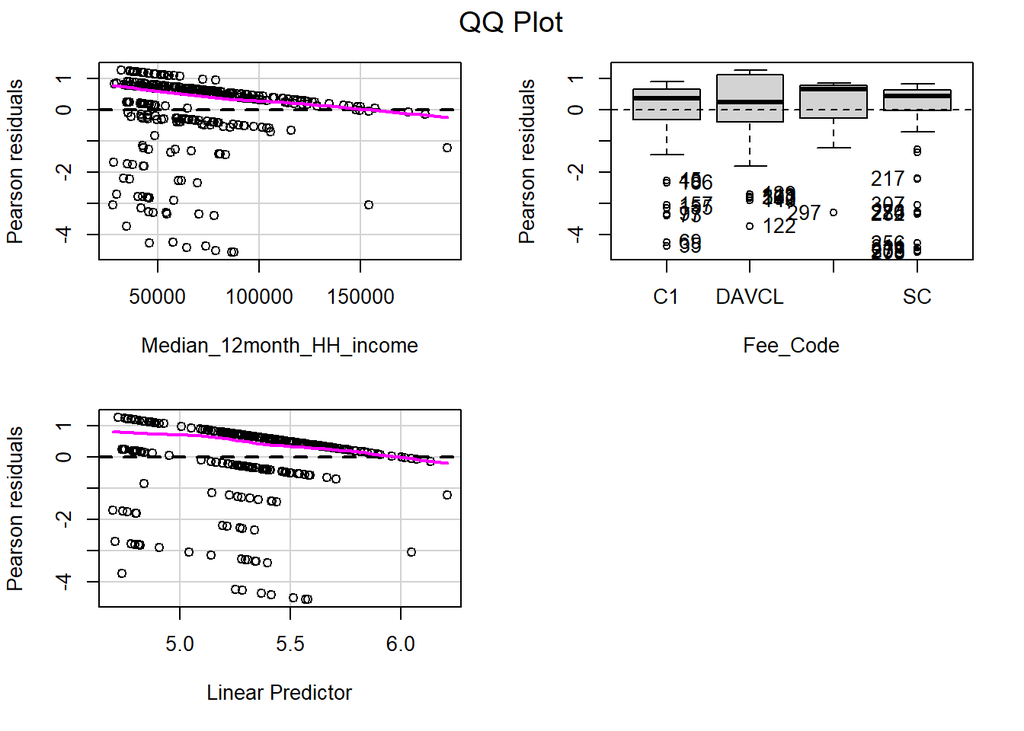

```
##                          Test stat Pr(>|Test stat|)
## Median_12month_HH_income    2.0059           0.1567
## Fee_Code
```

```r
residualPlots(m3, main="QQ Plot") #qq plot for studentized resid
```

Since there are considerable deviant residuals for this model, let’s try a more simple model with an intuitive and likely simpler dependent variable (total cash reserves).

```r
#create simple dataset for modeling that drops missing values and provides log transform
simpleModel <- allSmalls.requested.responded %>%
  select(PWSID, base.weight, final.weight.nonresponse, Service_Connections, delinquent_num_acc, cash_reserve_total, Fee_Code, Median_12month_HH_income) %>%
   mutate(log.d.n.acc = log10(delinquent_num_acc)) %>%
  mutate(log.cash.total = log10(cash_reserve_total)) %>%
  drop_na() %>%
  filter(log.d.n.acc > 0) %>%
  filter(log.cash.total > 0) %>%
  select(Service_Connections, log.d.n.acc, log.cash.total, PWSID, base.weight, final.weight.nonresponse, Service_Connections, delinquent_num_acc, cash_reserve_total, Fee_Code, Median_12month_HH_income) %>%
  droplevels()
#build glm
m5 <- glm(log.cash.total ~ Service_Connections + Median_12month_HH_income  + Fee_Code, na.action = na.exclude, data = simpleModel)
#report
summary(m5)
```

```
##
## Call:
## glm(formula = log.cash.total ~ Service_Connections + Median_12month_HH_income +
##     Fee_Code, data = simpleModel, na.action = na.exclude)
##
## Deviance Residuals:
##     Min       1Q   Median       3Q      Max
## -1.7542  -0.2662   0.0561   0.3109   1.6958
##
## Coefficients:
##                              Estimate   Std. Error t value             Pr(>|t|)
## (Intercept)               5.976528956  0.132823414  44.996 < 0.0000000000000002
## Service_Connections       0.000100326  0.000016102   6.231        0.00000000218
## Median_12month_HH_income  0.000001885  0.000001379   1.367                0.173
## Fee_CodeDAVCL             0.062504988  0.099081745   0.631                0.529
## Fee_CodeDAVCS            -1.030640099  0.190510953  -5.410        0.00000015735
## Fee_CodeSC               -1.042674500  0.113021073  -9.225 < 0.0000000000000002
##
## (Intercept)              ***
## Service_Connections      ***
## Median_12month_HH_income
## Fee_CodeDAVCL
## Fee_CodeDAVCS            ***
## Fee_CodeSC               ***
## ---
## Signif. codes:  0 '***' 0.001 '**' 0.01 '*' 0.05 '.' 0.1 ' ' 1
##
## (Dispersion parameter for gaussian family taken to be 0.2821804)
##
##     Null deviance: 174.486  on 236  degrees of freedom
## Residual deviance:  65.184  on 231  degrees of freedom
## AIC: 380.65
##
## Number of Fisher Scoring iterations: 2
```

Here we can see a much simpler model with a lower AIC (380.65) compared to the models that tried to predict months before assistance needed (AIC = 1079.7). We will use this simple relationship to calibrate the data. Let’s see this highly correlated relationship in graphical form.

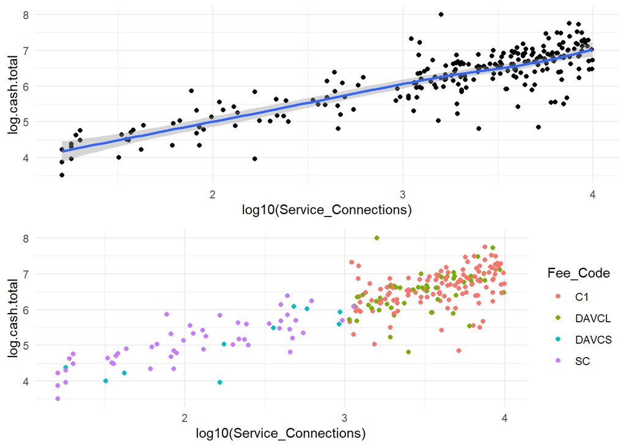

```r
p1 <- simpleModel %>%
  ggplot(aes(x = log10(Service_Connections), y = log.cash.total)) +
  geom_point() +
  geom_smooth()+
  theme_minimal()

p2 <- simpleModel %>%
  ggplot(aes(x = log10(Service_Connections), y = log.cash.total, color = Fee_Code)) +
  geom_point() +
  theme_minimal()
grid.arrange(p1, p2)
```

Here we can see the strong linear relationship between cash total and service connections, which will form the basis for building a model to rake the data.

### Calibration

```r
#get population totals for items of interest
N.PS <- xtabs(~Fee_Code, data = allSmalls)
```

```r
require(survey)
#build survey design with no weights
srv.dsgn.unweighted <- svydesign(ids = ~0,
                                 strata = ~tag,
                                 data = allSmalls.requested.responded,
                                 fpc = ~fpc,
                                 weights = ~NULL)
#build survey design with non-adjusted  weights
srv.dsgn.unadjusted <- svydesign(ids = ~ 0, # no clusters
                      strata = ~tag,
                      data = allSmalls.requested.responded,
                      fpc = ~fpc,
                      weights = ~base.weight)
#build survey design with adjusted non-response weights
srv.dsgn <- svydesign(ids = ~ 0, # no clusters
                      strata = ~tag,
                      data = allSmalls.requested.responded,
                      fpc = ~fpc,
                      weights = ~final.weight.nonresponse)
#PostStratify by fee code
ps.dsgn <- postStratify(design = srv.dsgn,
                        strata = ~Fee_Code,
                        partial = TRUE,
                        population = N.PS)

#IMPUTED WITH VOLUNTEERS
#filter non-responses
imputedSmalls.survey <- imputedSmalls.requested.voluntary %>% filter(responded == "y")

fpcID <- allSmalls %>% select(PWSID, fpc)
imputedSmalls.survey <- left_join(imputedSmalls.survey, fpcID)
#Build survey design with volunteer data and imputed values
srv.dsgn.imputed.volunteers <- svydesign(ids = ~ 0, # no clusters
                                         strata = ~tag,
                                         data = imputedSmalls.survey,
                                         fpc = ~fpc,
                                         weights = ~base.weight) #notice that base weights are used isntead of nonresponse adjusted as they dramatically overestimate

#postStratify with volunteer data and imputed values
ps.dsgn.imputed.volunteers <- postStratify(design = srv.dsgn.imputed.volunteers,
                                           strata = ~Fee_Code,
                                           partial = TRUE,
                                           population = N.PS)
```

```r
#if multiple post-strata are used, check that weights are calibrated
svytotal(~interaction(Fee_Code, tag), ps.dsgn)
```

```
##                                           total     SE
## interaction(Fee_Code, tag)C1.Bin A       0.0000 0.0000
## interaction(Fee_Code, tag)DAVCL.Bin A    0.0000 0.0000
## interaction(Fee_Code, tag)DAVCS.Bin A  238.0000 0.0000
## interaction(Fee_Code, tag)SC.Bin A    1697.5106 1.7289
## interaction(Fee_Code, tag)C1.Bin B     173.8424 4.7390
## interaction(Fee_Code, tag)DAVCL.Bin B   86.9667 3.2204
## interaction(Fee_Code, tag)DAVCS.Bin B    0.0000 0.0000
## interaction(Fee_Code, tag)SC.Bin B       2.4894 1.7289
## interaction(Fee_Code, tag)C1.Bin C      89.8013 3.3152
## interaction(Fee_Code, tag)DAVCL.Bin C   25.8109 2.7364
## interaction(Fee_Code, tag)DAVCS.Bin C    0.0000 0.0000
## interaction(Fee_Code, tag)SC.Bin C       0.0000 0.0000
## interaction(Fee_Code, tag)C1.Bin D      63.3563 2.1525
## interaction(Fee_Code, tag)DAVCL.Bin D   11.2224 1.3129
## interaction(Fee_Code, tag)DAVCS.Bin D    0.0000 0.0000
## interaction(Fee_Code, tag)SC.Bin D       0.0000 0.0000
```

Let’s compare the weights calculated from post-stratification with the non-reponse-adjusted weights and the volunteer imputed survey weights.

```r
#examine new weights
rbind(summary(weights(srv.dsgn)), summary(weights(ps.dsgn)), summary(weights(ps.dsgn.imputed.volunteers)))
```

```
##          Min.  1st Qu.   Median     Mean  3rd Qu.     Max.
## [1,] 1.336107 1.536479 2.539871 6.334232 11.03411 25.18421
## [2,] 1.402806 1.694364 2.800862 6.439353 10.72774 24.79048
## [3,] 1.274042 1.744200 2.645900 5.826829 10.22678 13.22222
```

We can see that post-stratification by fee code alone did not alter the weights significantly. This is not surprising due to the original survey design. However, significantly smaller weights are avilable for the post-stratified imputed survey set with volunteers (line 3).

The estimated proportion of fee codes and their their SEs are reported below for the post-stratified.

```r
svytotal(~Fee_Code, ps.dsgn, na.rm = TRUE)
```

```
##               total SE
## Fee_CodeC1      327  0
## Fee_CodeDAVCL   124  0
## Fee_CodeDAVCS   238  0
## Fee_CodeSC     1700  0
```

Coefficients of variation produced by the post-stratification are provided below.

```r
cv(svytotal(~Fee_Code, ps.dsgn, na.rm = TRUE))
```

```
##                Fee_CodeC1             Fee_CodeDAVCL             Fee_CodeDAVCS
## 0.00000000000000003372593 0.00000000000000001321392 0.00000000000000000000000
##                Fee_CodeSC
## 0.00000000000000001469199
```

If we compare these values to those in the original survey design (without post-stratification), we can see the differences in totals and standard errors.

```r
svytotal(~Fee_Code, srv.dsgn, na.rm = TRUE)
```

```
##                 total      SE
## Fee_CodeC1     296.53  9.0561
## Fee_CodeDAVCL  118.10  8.4569
## Fee_CodeDAVCS  186.82 44.4289
## Fee_CodeSC    1748.55 61.7973
```

```r
cv(svytotal(~Fee_Code, srv.dsgn, na.rm = TRUE))
```

```
##    Fee_CodeC1 Fee_CodeDAVCL Fee_CodeDAVCS    Fee_CodeSC
##    0.03054048    0.07160575    0.23782072    0.03534204
```

Since we also post-stratified the imputed data, we can view the total estimaes as well.

```r
svytotal(~Fee_Code, ps.dsgn.imputed.volunteers, na.rm = TRUE)
```

```
##               total SE
## Fee_CodeC1      327  0
## Fee_CodeDAVCL   124  0
## Fee_CodeDAVCS   238  0
## Fee_CodeSC     1700  0
```

Let’s see how the change in weights changes means for response variables.

```r
#calcualte unweighted means
srv.mean.unweighted <- svymean(~cash_reserve_total + cash_reserve_restricted + cash_reserve_unrestricted +
                         months_before_assist_num + delinquent_num_acc +
                           delinquent_amount_dollars,
                         srv.dsgn.unweighted, na.rm = TRUE)
srv.mean.unweighted <- data.frame(srv.mean.unweighted)
#reassign names
srv.mean.unweighted <- setNames(cbind(rownames(srv.mean.unweighted), srv.mean.unweighted, row.names = NULL),
         c("variable", "srv.Mean.unweighted", "srv.SE.unweighted"))

#calcualte un-adjusted weights means
srv.mean.unadjusted <- svymean(~cash_reserve_total + cash_reserve_restricted + cash_reserve_unrestricted +
                         months_before_assist_num + delinquent_num_acc +
                           delinquent_amount_dollars,
                         srv.dsgn.unadjusted, na.rm = TRUE)
srv.mean.unadjusted <- data.frame(srv.mean.unadjusted)
#reassign names
srv.mean.unadjusted <- setNames(cbind(rownames(srv.mean.unadjusted), srv.mean.unadjusted, row.names = NULL),
         c("variable", "srv.Mean.unadjusted", "srv.SE.unadjusted"))

#calcualte survey means
srv.mean <- svymean(~cash_reserve_total + cash_reserve_restricted + cash_reserve_unrestricted +
                         months_before_assist_num + delinquent_num_acc +
                           delinquent_amount_dollars,
                         srv.dsgn, na.rm = TRUE)
srv.mean <- data.frame(srv.mean)
#reassign names
srv.mean <- setNames(cbind(rownames(srv.mean), srv.mean, row.names = NULL),
         c("variable", "srv.Mean", "srv.SE"))
#calcualte post-stratification means
post.strat.mean  <-  svymean(~cash_reserve_total + cash_reserve_restricted +
                               cash_reserve_unrestricted +
                         months_before_assist_num + delinquent_num_acc +
                           delinquent_amount_dollars,
                         ps.dsgn, na.rm = TRUE)

post.strat.mean <- data.frame(post.strat.mean)
post.strat.mean <- setNames(cbind(rownames(post.strat.mean), post.strat.mean, row.names = NULL),
         c("variable", "post.strat.Mean", "post.strate.SE"))

#calcualte post-stratified means for IMPUTED data
srv.mean.imputed.volunteers <- svymean(~cash_reserve_total + cash_reserve_restricted + cash_reserve_unrestricted
                                       +
                         months_before_assist_num + delinquent_num_acc +
                           delinquent_amount_dollars,
                         srv.dsgn.imputed.volunteers, na.rm = TRUE)
srv.mean.imputed.volunteers <- data.frame(srv.mean.imputed.volunteers)
#reassign names
srv.mean.imputed.volunteers <- setNames(cbind(rownames(srv.mean.imputed.volunteers), srv.mean.imputed.volunteers, row.names = NULL),
         c("variable", "srv.mean.imputed.volunteers", "srv.SE.imputed.volunteers"))


#join tables
left_join(left_join(left_join(left_join(srv.mean,post.strat.mean, by = "variable"), srv.mean.unadjusted),srv.mean.unweighted), srv.mean.imputed.volunteers)
```

```
##                    variable       srv.Mean         srv.SE post.strat.Mean
## 1        cash_reserve_total 2527446.336860 357307.3668179  2706958.226778
## 2   cash_reserve_restricted 1182049.825459 178861.9075251  1258589.425078
## 3 cash_reserve_unrestricted 1344814.476398 187478.1392755  1447767.853585
## 4  months_before_assist_num       5.466946      0.1096564        5.462841
## 5        delinquent_num_acc     116.365700     12.3952600      123.613310
## 6 delinquent_amount_dollars   39012.837716   3944.8250461    41460.261242
##   post.strate.SE srv.Mean.unadjusted srv.SE.unadjusted srv.Mean.unweighted
## 1 380361.4034248      2800683.209568    376744.2372961       6031301.70850
## 2 190155.1240098      1301756.461640    190503.2978393       2755305.03562
## 3 199361.6189814      1498309.609307    196452.4371797       3274884.89510
## 4      0.1058211            5.444545         0.1136778             5.24183
## 5     12.7502567          131.614702        12.8824027           326.66013
## 6   4082.4875245        44208.031327      4073.4695931        111170.44039
##   srv.SE.unweighted srv.mean.imputed.volunteers srv.SE.imputed.volunteers
## 1   512879.54059162              2730656.601597            351280.4812604
## 2   278262.91363005              1217608.244469            176047.8589148
## 3   267381.10357436              1412763.413324            182333.2919908
## 4        0.07134897                    5.465142                 0.1056953
## 5       21.84078869                  123.359770                11.8857438
## 6     7160.12974554                47312.721894              5357.0913608
```

```r
# construct and display a frequency table STRATIFIED
tab_fee_need_cond <- svytable(~Fee_Code + months_before_assist,
                         design = ps.dsgn) %>%
  # Add conditional proportions to table
    as.data.frame() %>%
    group_by(Fee_Code) %>%
    mutate(n_Fee_Code = sum(Freq), Prop_Need = Freq/n_Fee_Code) %>%
    ungroup()
# repeate for unweighted
tab_fee_need_cond_unwt <- svytable(~Fee_Code + months_before_assist,
                         design = srv.dsgn.unweighted) %>%
  # Add conditional proportions to table
    as.data.frame() %>%
    group_by(Fee_Code) %>%
    mutate(n_Fee_Code = sum(Freq), Prop_Need = Freq/n_Fee_Code) %>%
    ungroup()
#repeat for volunteers and imputed data
tab_fee_need_cond_imputed <- svytable(~Fee_Code + months_before_assist,
                         design = srv.dsgn.imputed.volunteers) %>%
  # Add conditional proportions to table
    as.data.frame() %>%
    group_by(Fee_Code) %>%
    mutate(n_Fee_Code = sum(Freq), Prop_Need = Freq/n_Fee_Code) %>%
    ungroup()
```

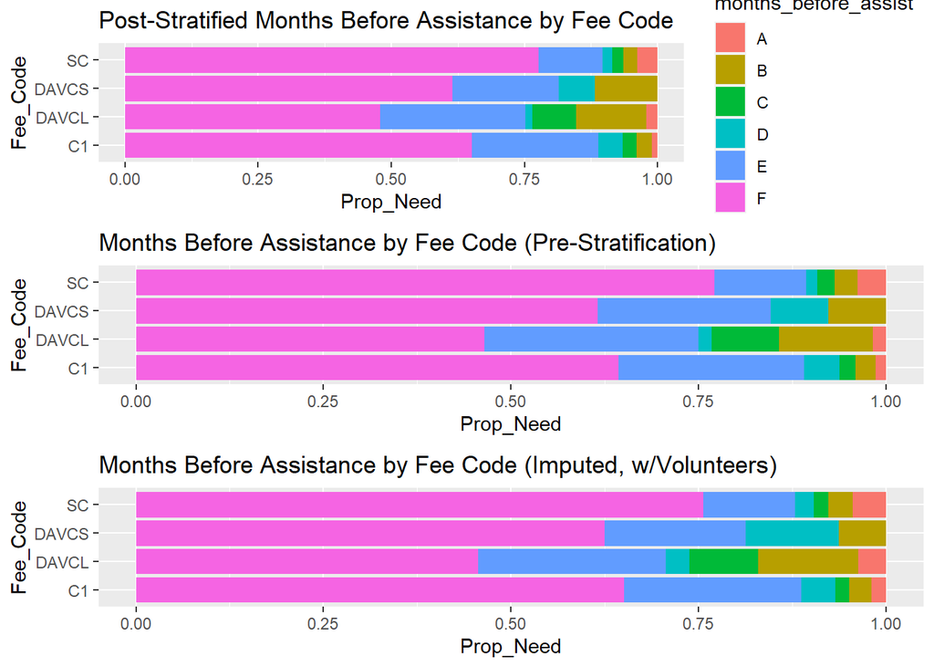

```r
# Create a segmented bar graph of the conditional proportions in table
p1 <- ggplot(data = tab_fee_need_cond,
       mapping = aes(x = Fee_Code, y = Prop_Need, fill = months_before_assist)) +
  geom_col() +
  coord_flip() +
  labs(title = "Post-Stratified Months Before Assistance by Fee Code",
       xlab = "Proportion")
#before strat
p2 <- ggplot(data = tab_fee_need_cond_unwt,
       mapping = aes(x = Fee_Code, y = Prop_Need, fill = months_before_assist)) +
  geom_col() +
  coord_flip() +
  labs(title = "Months Before Assistance by Fee Code (Pre-Stratification)",
       xlab = "Proportion") +
  theme(legend.position = "none")
# Imputed with volunteers
p3 <- ggplot(data = tab_fee_need_cond_imputed,
       mapping = aes(x = Fee_Code, y = Prop_Need, fill = months_before_assist)) +
  geom_col() +
  coord_flip() +
  labs(title = "Months Before Assistance by Fee Code (Imputed, w/Volunteers)",
       xlab = "Proportion") +
  theme(legend.position = "none")

grid.arrange(p1, p2, p3)
```

We can see that the weighing does not apprecitably change the results. However there does seem to be a slight change in the number of disadvantaged community larges with immediate need in the volunteer group with imputation.

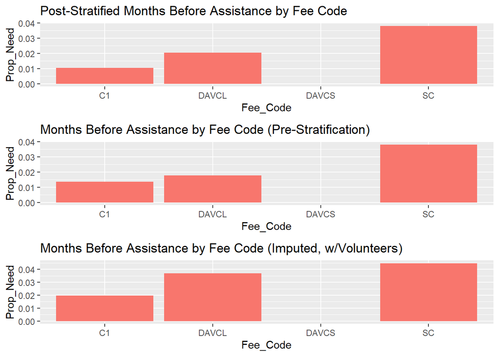

```r
# Create a segmented bar graph of the conditional proportions in table
p1 <- tab_fee_need_cond %>%
  filter(months_before_assist == "A") %>%
  ggplot(mapping = aes(x = Fee_Code, y = Prop_Need, fill = months_before_assist)) +
  geom_col() +

  labs(title = "Post-Stratified Months Before Assistance by Fee Code",
       xlab = "Proportion")+
  theme(legend.position = "none")
#before strat
p2 <- tab_fee_need_cond_unwt %>%
  filter(months_before_assist == "A") %>%
  ggplot(
       mapping = aes(x = Fee_Code, y = Prop_Need, fill = months_before_assist)) +
  geom_col() +
  labs(title = "Months Before Assistance by Fee Code (Pre-Stratification)",
       xlab = "Proportion") +
  theme(legend.position = "none")
# Imputed with volunteers
p3 <- tab_fee_need_cond_imputed %>%
   filter(months_before_assist == "A") %>%
  ggplot(
       mapping = aes(x = Fee_Code, y = Prop_Need, fill = months_before_assist)) +
  geom_col() +
  labs(title = "Months Before Assistance by Fee Code (Imputed, w/Volunteers)",
       xlab = "Proportion") +
  theme(legend.position = "none")

grid.arrange(p1, p2, p3)
```

Our survey has now been weighted to adequately represent fee code distributions.

Now that we have our adjusted weights, let’s extract them and bind to the dataframes.

```r
#bind post-stratified weights to all smalls (no volunteers)
allSmalls.requested.responded <- cbind(allSmalls.requested.responded, weights(ps.dsgn))
#bind post-stratified weights to imputed survey with volunteers
imputedSmalls.survey <- cbind(imputedSmalls.survey, weights(ps.dsgn.imputed.volunteers))

#Save to csv
# write.csv(x = allSmalls.requested.responded %>%
#              select(PWSID,`weights(ps.dsgn)`),
#            file = "Datasets/noVolunteerSurveyWEIGHTS.csv"
#            )

#Save to csv
# write.csv(x = imputedSmalls.survey %>%
#             select(PWSID,`weights(ps.dsgn.imputed.volunteers)`),
#           file = "Datasets/fullSurveyWEIGHTS.csv"
#           )
#Save to csv
write.csv(x = imputedSmalls.survey,
           file = "Datasets/fullSurveyIMPUTED.csv")
```

# Blending Probability and Non-Probability Samples

Note that some systems that were not requested to participate in the survey did. Let’s see how many.

```r
#wide format for table viewing
allSmalls %>% group_by(tag) %>% filter(voluntary == "n" | voluntary == "y") %>%  summarize(percent.voluntary = sum(volunteered)/n()*100, volunteered.sum = sum(volunteered))
```

```
## # A tibble: 4 x 3
##   tag   percent.voluntary volunteered.sum
##   <fct>             <dbl>           <dbl>
## 1 Bin A             16.3               30
## 2 Bin B              7.62               8
## 3 Bin C              1.43               1
## 4 Bin D              0                  0
```

These data can also be visualized in a plot. Further annotated with the voluntary responses received.

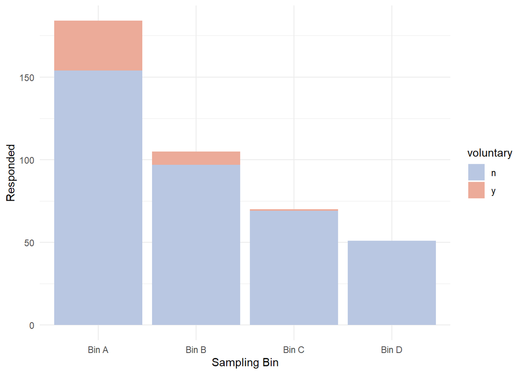

```r
#plot
allSmalls %>% filter(voluntary == "n" | voluntary == "y") %>%
  ggplot(aes(x = tag, fill = voluntary)) +
  geom_bar(position = position_stack(reverse = TRUE))+
  scale_fill_manual(values = cal_palette("superbloom1")) +
  scale_x_discrete(name = "Sampling Bin") +
  scale_y_continuous(name = "Responded") +
  theme_minimal()
```

Here we can see a clear trend of more voluntary responses from the smaller systems (Bins A and B). Perhaps this is reflective of their need to be recognized by the State due to economic hardships. This hypothesis may be tested using a general linear model with a binomial distribution.

```r
# build model
volunteerGLM <- glm(volunteered ~ cash_days + cash + Median_12month_HH_income + Service_Connections + months_before_assist, na.action = na.omit,
            data = allSmalls.responded, family = "binomial")
#print
summary(volunteerGLM)
```

```
##
## Call:
## glm(formula = volunteered ~ cash_days + cash + Median_12month_HH_income +
##     Service_Connections + months_before_assist, family = "binomial",
##     data = allSmalls.responded, na.action = na.omit)
##
## Deviance Residuals:
##      Min        1Q    Median        3Q       Max
## -1.44912  -0.49751  -0.29004  -0.08801   2.98273
##
## Coefficients:
##                                Estimate     Std. Error z value Pr(>|z|)
## (Intercept)               1.86959698003  1.10730501431   1.688 0.091330 .
## cash_days                -0.00017284327  0.00012994702  -1.330 0.183483
## cash                      0.00000006546  0.00000003404   1.923 0.054477 .
## Median_12month_HH_income -0.00001543640  0.00000945336  -1.633 0.102490
## Service_Connections      -0.00079634006  0.00022251484  -3.579 0.000345 ***
## months_before_assistB    -1.77255345936  1.20304974268  -1.473 0.140648
## months_before_assistC    -1.85240244008  1.46403370068  -1.265 0.205773
## months_before_assistD    -0.43975799289  1.19682620398  -0.367 0.713293
## months_before_assistE    -2.74959827259  1.07491098229  -2.558 0.010528 *
## months_before_assistF    -2.35135068103  0.93050371917  -2.527 0.011505 *
## ---
## Signif. codes:  0 '***' 0.001 '**' 0.01 '*' 0.05 '.' 0.1 ' ' 1
##
## (Dispersion parameter for binomial family taken to be 1)
##
##     Null deviance: 191.83  on 305  degrees of freedom
## Residual deviance: 151.83  on 296  degrees of freedom
##   (104 observations deleted due to missingness)
## AIC: 171.83
##
## Number of Fisher Scoring iterations: 7
```

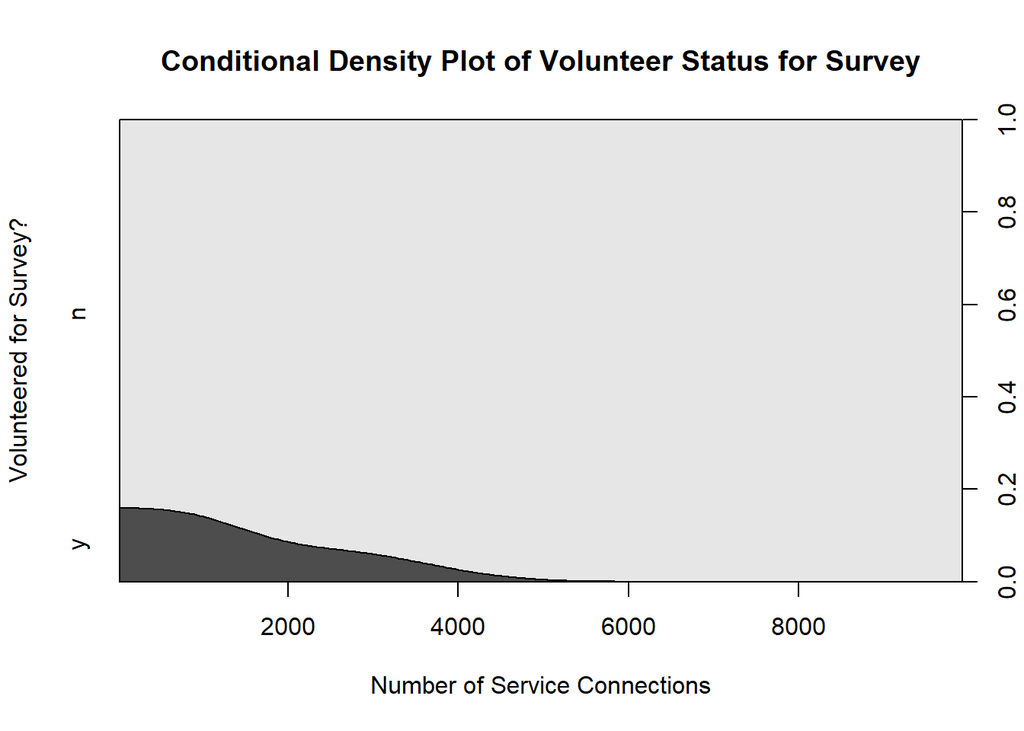

```r
p1 <- allSmalls.responded %>% droplevels()

cdplot(voluntary ~ Service_Connections, data =p1,
       main = "Conditional Density Plot of Volunteer Status for Survey", xlab = "Number of Service Connections", ylab = "Volunteered for Survey?")
```

Here we can more clearly see this extremely significant inverse trend between number of service connections and probability to participate in the survey voluntarily. Nearly all of these volunteers are in the “smalls” fee code categories (DAVCS and CS).

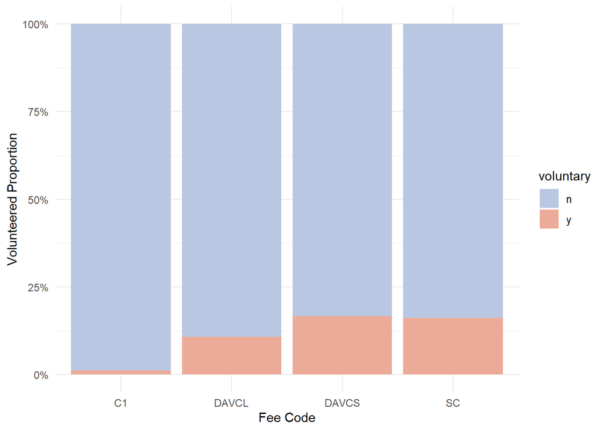

```r
#plot
allSmalls %>% filter(voluntary == "n" | voluntary == "y") %>%
  ggplot(aes(x = Fee_Code, fill = voluntary)) +
  geom_bar(position = "fill")+
  scale_fill_manual(values = cal_palette("superbloom1")) +
  scale_x_discrete(name = "Fee Code") +
  scale_y_continuous(name = "Volunteered Proportion", labels = scales::percent) +
  theme_minimal()
```

Since these voluntary samples are not equally distributed amongst classes, they are nonprobability samples. Since census information is available for the population (i.e. service connections, fee code, districts, etc.), these samples may still be used for further analysis by sub-sampling a representative sample from this list using *sample matching* methods. The theory for matching nonprobability volunteer samples with probability samples is described by [Rubin (1979)](https://www.jstor.org/stable/2286330).